# pre_lab_11.Rmd

a silly little spatial join

8/24/2021

## Chapter 20

Up to now, we’ve been looking at patterns in data for what is more than this, or what’s the middle look like. We’ve calculated metrics like per capita rates, or looked at how data changes over time.

Another way we can look at the data is geographically. Is there a spatial pattern to our data? Can we learn anything by using distance as a metric? What if we merge non-geographic data into geographic data?

The bad news is that there isn’t a One Library To Rule Them All when it comes to geo queries in R. But there’s one emerging, called Simple Features, that is very good.

Go to the console and install it with `install.packages("sf")`

To understand geographic queries, you have to get a few things in your head first:

1. Your query is using planar space. Usually that’s some kind of projection of the world. If you’re lucky, your data is projected, and the software will handle projection differences under the hood without you knowing anything about it.
2. Projections are cartographers making opinionated decisions about what the world should look like when you take a spheroid – the earth isn’t perfectly round – and flatten it. Believe it or not, every state in the US has their own geographic projection. There’s dozens upon dozens of them.
3. Geographic queries work in layers. In most geographic applications, you’ll have multiple layers. You’ll have a boundary file, and a river file, and a road file, and a flood file and combined together they make the map. But you have to think in layers.
4. See 1. With layers, they’re all joined together by the planar space. So you don’t need to join one to the other like we did earlier – the space has done that. So you can query how many X are within the boundaries on layer Y. And it’s the plane that holds them together.

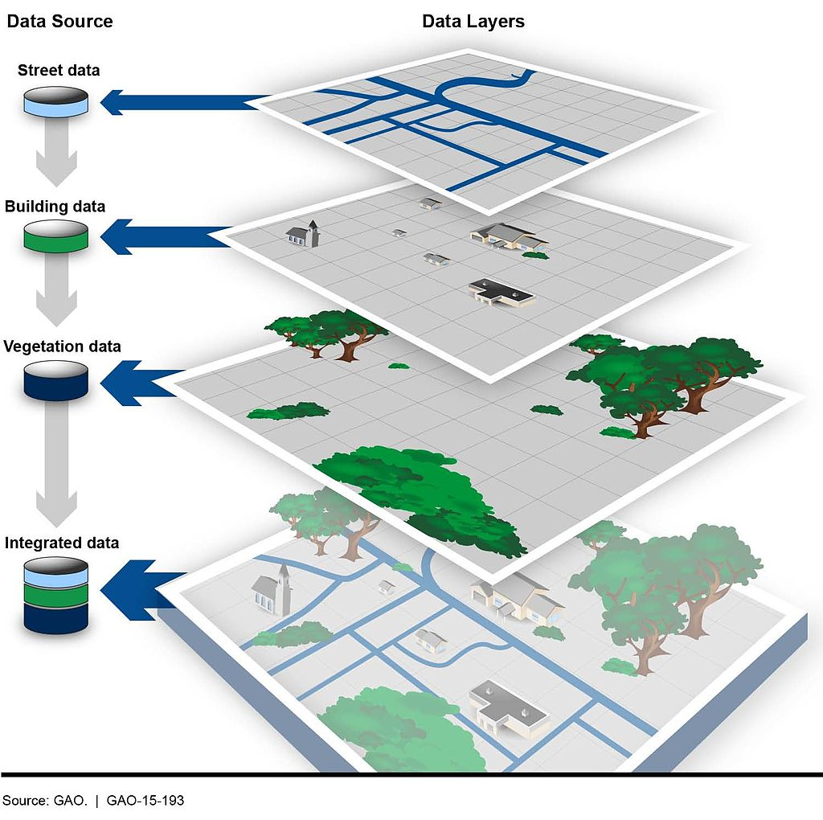

## Importing and viewing data

Let’s start with the absolute basics of geographic data: loading and viewing. Load libraries as usual.

### Task 1: Load packages

**Task** Run the following code to load packages.

```r
library(tidyverse)
library(sf)
library(janitor)
```

First: an aside on geographic data. There are many formats for geographic data, but data type you’ll see the most is called the shapefile. It comes from a company named ERSI, which created the most widely used GIS software in the world. For years, they were the only game in town, really, and the shapefile became ubiquitous, especially so in government and utilities.

So more often than not, you’ll be dealing with a shapefile. But a shapefile isn’t just a single file – it’s a collection of files that combined make up all the data that allow you to use it. There’s a .shp file – that’s the main file that pulls it all together – but it’s important to note if your shapefiles has a .prj file, which indicates that the projection is specified.

The data we’re going to be working with is a file from the Department of Homeland Security that is every hospital in the US and the number of beds they have. I’m writing this during the days of coronavirus, and suddenly the number of hospital beds is a top concern. So let’s look at where hospital beds are and how many of them are there.

When you do, it should look something like this:

### Task: Load image

**Task** Run the following code to load an image. Describe what you see in the answer space below. **Answer** A bunch of files, that all make up a shapefile.

[figure not shown]

Simlar to `readr`, the `sf` library has functions to read geographic data. In this case, we’re going to use `st_read` to read in our hospitals data. And then glimpse it to look at the columns.

### Task: Load data

**Task** Run the following code to load data. Describe what you see in the answer space below. What columns exist in this data? **Answer** Data about hospitals that also includes geometric point data.

```r
hospitals <- st_read("data/Hospitals/Hospitals.shp")
glimpse(hospitals)
```

```
## Rows: 7,581
## Columns: 33
## $ OBJECTID   <dbl> 1, 2, 3, 4, 5, 6, 7, 8, 9, 10, 11, 12, 13, 14, 15, 16, 17, …
## $ ID         <chr> "0005793230", "0053391362", "0011190023", "0017090028", "00…
## $ NAME       <chr> "CENTRAL VALLEY GENERAL HOSPITAL", "LOS ROBLES HOSPITAL & M…
## $ ADDRESS    <chr> "1025 NORTH DOUTY STREET", "150 VIA MERIDA", "4060 WHITTIER…
## $ CITY       <chr> "HANFORD", "WESTLAKE VILAGE", "LOS ANGELES", "HOLLYWOOD", "…
## $ STATE      <chr> "CA", "CA", "CA", "CA", "CA", "CA", "CA", "CA", "CA", "CA",…
## $ ZIP        <chr> "93230", "91362", "90023", "90028", "91706", "90712", "9101…
## $ ZIP4       <chr> "NOT AVAILABLE", "NOT AVAILABLE", "NOT AVAILABLE", "NOT AVA…
## $ TELEPHONE  <chr> "NOT AVAILABLE", "NOT AVAILABLE", "NOT AVAILABLE", "(323) 4…
## $ TYPE       <chr> "GENERAL ACUTE CARE", "GENERAL ACUTE CARE", "GENERAL ACUTE …
## $ STATUS     <chr> "CLOSED", "OPEN", "OPEN", "OPEN", "OPEN", "OPEN", "OPEN", "…
## $ POPULATION <dbl> 49, 62, 127, 100, 95, 172, 49, 101, 16, 78, 87, 269, 42, 27…
## $ COUNTY     <chr> "KINGS", "VENTURA", "LOS ANGELES", "LOS ANGELES", "LOS ANGE…
```

[output cut: 20 more lines]

This looks like a normal dataframe, and mostly it is. We have one row per hospital, and each column is some feature of that hospital: the name, the address, it’s open/closed status and more. What sets this data apart from other dataframes we’ve used is the last column, “geometry”, which is of a new data type. It’s not a character or a number, it’s a “POINT”, which is composed of a longitude value and a latitude value. When we plot these on a grid of latitude and longitude, it will place a point where those two numbers intersect.

Let’s look at just Maryland hospitals. Good news – `sf` plays very nicely with the tidyverse, so we can filter data the way we are accustomed.

### Task: Run code

**Task** Run the following code. Describe the output in the space below. **Answer** Hospitals only within Maryland.

```r
md_hospitals <- hospitals %>%
  filter(STATE == "MD")

md_hospitals
```

```
## Simple feature collection with 72 features and 32 fields
## Geometry type: POINT
## Dimension:     XY
## Bounding box:  xmin: -79.40098 ymin: 37.99756 xmax: -75.21133 ymax: 39.677
## Geodetic CRS:  WGS 84
## First 10 features:
##    OBJECTID         ID
## 1       234 0003120785
## 2       364 0000921287
## 3       365 0001021205
## 4       366 0002321202
## 5       367 0003721215
## 6       368 0004121201
## 7       370 0004821224
## 8       397 0003421740
```

[output cut: 112 more lines]

We have 72 hospitals, according to this data.

What kind of hospitals do we have?

### Task: Run code

**Task** Run the following code. Describe the output in the space below. **Answer** A table of the type of hospitals.

```r
md_hospitals %>%
  group_by(TYPE) %>%
  summarise(
    count=n()
  ) %>%
  arrange(desc(count))
```

```
## Simple feature collection with 7 features and 2 fields
## Geometry type: GEOMETRY
## Dimension:     XY
## Bounding box:  xmin: -79.40098 ymin: 37.99756 xmax: -75.21133 ymax: 39.677
## Geodetic CRS:  WGS 84
## # A tibble: 7 × 3
##   TYPE               count                                              geometry
##   <chr>              <int>                                        <GEOMETRY [°]>
## 1 GENERAL ACUTE CARE    50 MULTIPOINT ((-79.40098 39.41344), (-77.24226 39.1806…
## 2 PSYCHIATRIC           11 MULTIPOINT ((-77.19896 39.09986), (-76.98002 39.0025…
## 3 MILITARY               4 MULTIPOINT ((-77.09359 39.00129), (-76.06292 39.5499…
## 4 CHRONIC DISEASE        2 MULTIPOINT ((-76.92156 38.93088), (-75.59572 38.3823…
## 5 LONG TERM CARE         2 MULTIPOINT ((-76.66465 39.35458), (-77.71631 39.6624…
## 6 REHABILITATION         2 MULTIPOINT ((-77.20068 39.09859), (-75.54862 38.3692…
## 7 SPECIAL                1                            POINT (-76.80099 39.37272)
```

Let’s narrow our data to only look at the 50 “General Acute Care hospitals.”

### Task: Run code

**Task** Run the following code. Describe the output in the space below. **Answer** Hospitals that are general acute care.

```r
md_hospitals <- hospitals %>%
  filter(STATE == "MD") %>%
  filter(TYPE == "GENERAL ACUTE CARE")

md_hospitals
```

```
## Simple feature collection with 50 features and 32 fields
## Geometry type: POINT
## Dimension:     XY
## Bounding box:  xmin: -79.40098 ymin: 37.99756 xmax: -75.21133 ymax: 39.64783
## Geodetic CRS:  WGS 84
## First 10 features:
##    OBJECTID         ID                                     NAME
## 1       364 0000921287                   JOHNS HOPKINS HOSPITAL
## 2       365 0001021205                KENNEDY KREIGER INSTITUTE
## 3       366 0002321202                     MERCY MEDICAL CENTER
## 4       367 0003721215              SINAI HOSPITAL OF BALTIMORE
## 5       368 0004121201    UNIVERSITY OF MARYLAND MEDICAL CENTER
## 6       370 0004821224     JOHNS HOPKINS BAYVIEW MEDICAL CENTER
## 7       404 0003521742                   MERITUS MEDICAL CENTER
## 8       443 0001920910                      HOLY CROSS HOSPITAL
```

[output cut: 101 more lines]

That gives us 50 hospitals in Maryland. Where are they?

We can simply plot them on a longitude-latitude grid using ggplot.

### Task: Run code

**Task** Run the following code. Describe the output in the space below. **Answer** A plot of coordinates.

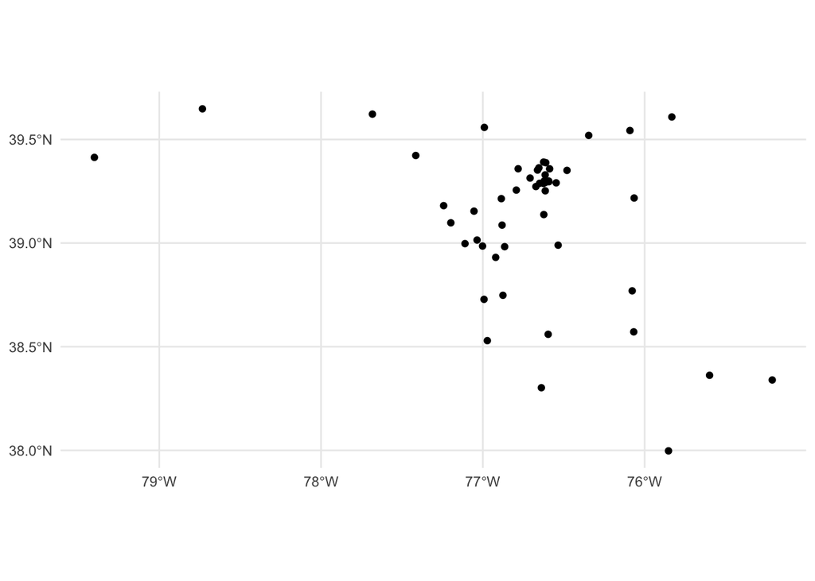

```r
md_hospitals %>%
  ggplot() +
  geom_sf() +
  theme_minimal()
```

Each point is a hospital. Each hospital has been plotted according to its degrees of longitude and latitude.

If you know anything about the state of Maryland, you can kinda pick out the shape of the state there. The point in the top left is in Western Maryland. The point at the extreme bottom right is on the Eastern Shore. But this map is not exactly ideal. It would help to have a state and county map layered underneath of it, to help make sense of the spatial nature of this data.

This is where layering becomes more clear. First, we want to go out and get another shapefile, this one showing Maryland county outlines.

Instead of loading it from our local machine, like we did above, we’re going to use a package to directly download it from the U.S. Census. The package is called `tigris` and it’s developed by the same person who made `tidycensus`.

In the console, install tigris with `install.packages('tigris')`

Then load it:

### Task: Run code

**Task** Run the following code. Describe the output in the space below. **Answer** Loaded tigris.

```r
# install.packages('tigris')
library(tigris)
```

Now, let’s use the counties() function from tigris to pull down a shapefile of all U.S. counties.

### Task: Run code

**Task** Run the following code. Describe the output in the space below. **Answer** County information.

```r
counties <- counties()
glimpse(counties)
```

```
## Rows: 3,233
## Columns: 18
## $ STATEFP  <chr> "31", "53", "35", "31", "31", "72", "46", "48", "06", "21", "…
## $ COUNTYFP <chr> "039", "069", "011", "109", "129", "085", "099", "327", "091"…
## $ COUNTYNS <chr> "00835841", "01513275", "00933054", "00835876", "00835886", "…
## $ GEOID    <chr> "31039", "53069", "35011", "31109", "31129", "72085", "46099"…
## $ NAME     <chr> "Cuming", "Wahkiakum", "De Baca", "Lancaster", "Nuckolls", "L…
## $ NAMELSAD <chr> "Cuming County", "Wahkiakum County", "De Baca County", "Lanca…
## $ LSAD     <chr> "06", "06", "06", "06", "06", "13", "06", "06", "06", "06", "…
## $ CLASSFP  <chr> "H1", "H1", "H1", "H1", "H1", "H1", "H1", "H1", "H1", "H1", "…
## $ MTFCC    <chr> "G4020", "G4020", "G4020", "G4020", "G4020", "G4020", "G4020"…
## $ CSAFP    <chr> NA, NA, NA, "339", NA, "490", NA, NA, NA, NA, "534", "352", N…
## $ CBSAFP   <chr> NA, NA, NA, "30700", NA, "41980", "43620", NA, NA, NA, "22300…
## $ METDIVFP <chr> NA, NA, NA, NA, NA, NA, NA, NA, NA, NA, NA, NA, NA, NA, NA, N…
## $ FUNCSTAT <chr> "A", "A", "A", "A", "A", "A", "A", "A", "A", "A", "A", "A", "…
## $ ALAND    <dbl> 1477652222, 680962890, 6016819475, 2169270569, 1489645188, 87…
## $ AWATER   <dbl> 10690952, 61582307, 29089486, 22849484, 1718484, 32509, 18198…
## $ INTPTLAT <chr> "+41.9158651", "+46.2946377", "+34.3592729", "+40.7835474", "…
## $ INTPTLON <chr> "-096.7885168", "-123.4244583", "-104.3686961", "-096.6886584…
## $ geometry <MULTIPOLYGON [°]> MULTIPOLYGON (((-97.01952 4..., MULTIPOLYGON (((…
```

This looks pretty similar to our hospital shapefile, in that it looked mostly like a normal dataframe with the exception of the new geometry column.

But instead of POINT, this geometry is of the datatype “MULTIPOLYGON”. Points are shape data represented by one pair of longitude or latitude coordinates. Polygons are made up of LOTS of pairs of longitude and latitude coordinates, connected by a boundary line into a complex shape.

If you’ve ever filled in a “connect the dots” picture by drawing lines between points, in order to reveal a hidden shape, then you’re familiar with the concept.

This county shapefile has all 3233 U.S. counties. We only want the Maryland counties, so we’re going to filter the data to only keep Maryland counties. There is no STATE column, but there is a STATEFP column, with each number representing a state. Maryland’s FP number is 24.

### Task: Run code

**Task** Run the following code. Describe the output in the space below. **Answer** Counties but filtered for only in Maryland.

```r
md_counties <- counties %>%
  filter(STATEFP == "24")
```

To see what this looks like, let’s plot it out with ggplot. We can pretty clearly see the shapes of Maryland counties.

### Task: Run code

**Task** Run the following code. Describe the output in the space below. **Answer** Counties outlined!

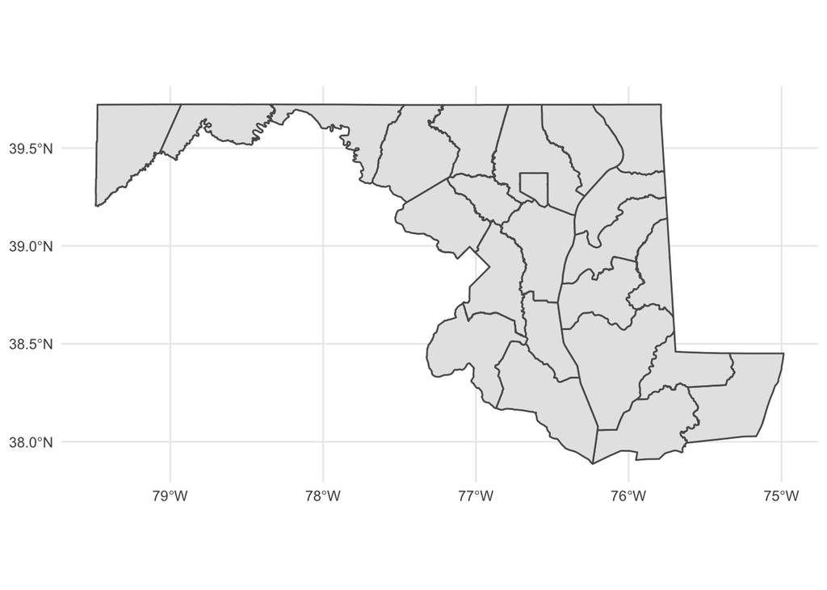

```r
md_counties %>%
  ggplot() +
  geom_sf() +
  theme_minimal()
```

With this county map, we can layer our hospital data.

Something to note: The layers are rendered in the order they appear. So the first geom_sf is rendered first. The second geom_sf is rendered ON TOP OF the first one.

We’re also going to change things up a bit to put the datasets we want to display INSIDE of the geom_sf() function, instead of starting with a dataframe. We have two to plot now, so it’s easier this way.

### Task: Run code

**Task** Run the following code. Describe the output in the space below. **Answer** Counties outlined, with points where the hospitals.

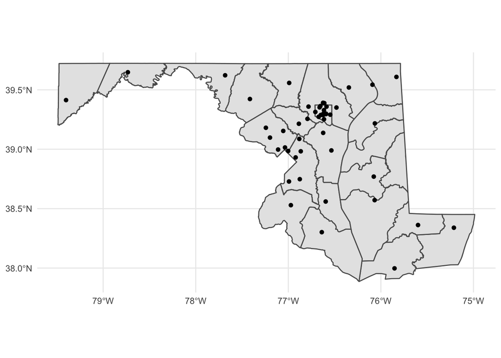

```r
ggplot() +
  geom_sf(data=md_counties) +
  geom_sf(data=md_hospitals) +
  theme_minimal()
```

What can we tell from this?

Well, hospitals are clustered around the state’s most populous areas, the Baltimore to Washington corridor. There are fewer hospitals in rural Eastern and Western counties. And two counties have no hospital at all.

This is a pretty blunt visualization. Not all hospitals are equal. Some have more beds than the others, and bed space is a critical factor in how full hospitals get during COVID-19 surges.

We can get a sense of where the largest hospitals are, by changing the color of the points according to the number of beds. We do this by setting the aesthetic – or aes – to use the BEDS column inside of the geom_sf function. To make the differences easier to see, we’re going to change the fill of the counties white, too, and use a special color palette, viridis magma. We’re also going to make the points slightly bigger.

### Task: Run code

**Task** Run the following code. Describe the output in the space below. **Answer** A map with points of the hospitals, and a colored legend corresponding to the number of beds.

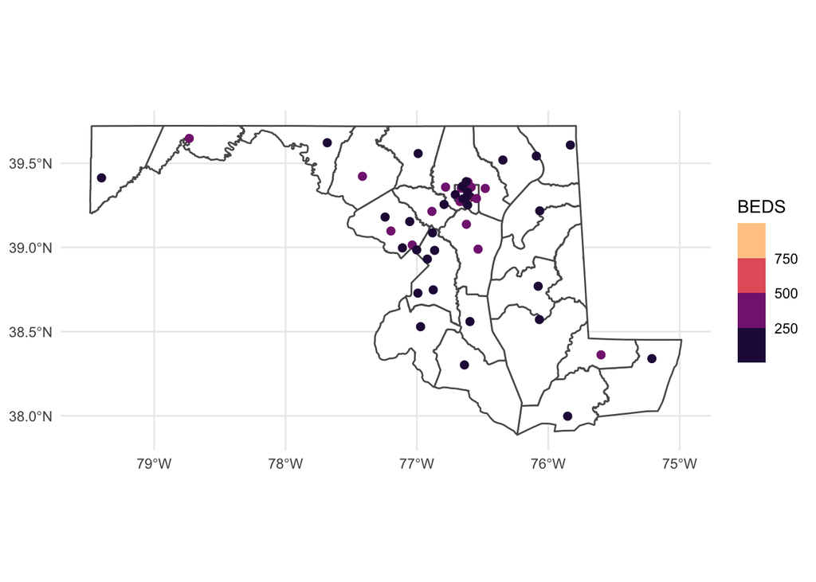

```r
ggplot() +
  geom_sf(data=md_counties, fill="white") +
  geom_sf(data=md_hospitals, aes(color=BEDS), size=2) +
  scale_colour_viridis_b(option="magma") +
  theme_minimal()
```

With these changes, what else can we make out here? Well, not only are most hospitals clustered in the center of Maryland, the largest ones are too. Rural areas have fewer and typically smaller hospitals.

## Chapter 21

In the previous chapter, we looked at Maryland’s hospitals and used layers to show where hospitals sit on a map of Maryland’s counties, and to show a bit of a pattern regarding concentration of the largest hospitals. Let’s go little further.

First, let’s load the libraries we’ll need. We’re also going to load tidycensus and set an API key for tidycensus.

### Task: Load libraries

**Task** Run the following code. Describe the output in the space below. Be sure to input your census api key. **Answer** Census api key!

```r
library(tidyverse)
library(sf)
library(janitor)
library(tidycensus)
census_api_key("82c33dd2db316b78367d3476bcb90d2abe65a69a", install = "TRUE", overwrite = TRUE)
```

```
## Your original .Renviron will be backed up and stored in your R HOME directory if needed.
```

```
## Your API key has been stored in your .Renviron and can be accessed by Sys.getenv("CENSUS_API_KEY").
## To use now, restart R or run `readRenviron("~/.Renviron")`
```

```
## [1] "82c33dd2db316b78367d3476bcb90d2abe65a69a"
```

And now let’s load the dataframe of hospital information from the previous chapter, and filter for the 50 General Acute Care hospitals in Maryland.

### Task: Run code

**Task** Run the following code. Describe the output in the space below. **Answer** Hospitals in maryland that are general acute care with point data.

```r
md_hospitals <- st_read("data/Hospitals/Hospitals.shp") %>%
  filter(STATE == "MD") %>%
  filter(TYPE == "GENERAL ACUTE CARE")
md_hospitals
```

```
## Simple feature collection with 50 features and 32 fields
## Geometry type: POINT
## Dimension:     XY
## Bounding box:  xmin: -79.40098 ymin: 37.99756 xmax: -75.21133 ymax: 39.64783
## Geodetic CRS:  WGS 84
## First 10 features:
##    OBJECTID         ID                                     NAME
## 1       364 0000921287                   JOHNS HOPKINS HOSPITAL
## 2       365 0001021205                KENNEDY KREIGER INSTITUTE
## 3       366 0002321202                     MERCY MEDICAL CENTER
## 4       367 0003721215              SINAI HOSPITAL OF BALTIMORE
## 5       368 0004121201    UNIVERSITY OF MARYLAND MEDICAL CENTER
## 6       370 0004821224     JOHNS HOPKINS BAYVIEW MEDICAL CENTER
## 7       404 0003521742                   MERITUS MEDICAL CENTER
## 8       443 0001920910                      HOLY CROSS HOSPITAL
```

[output cut: 101 more lines]

For the rest of this chapter, we’re going to work on building a map that will help us gain insight into geographic patterns in hospital bed availability by county in Maryland. Our question: by examining the number of hospital beds per 100,000 people in each county, what regional geographic patterns can we identify?

Each hospital exists inside of a county, so we’re going to first calculate the total number of beds in each county. We do this by first converting the md_hospitals data to a standard dataframe (instead of a spatial dataframe) using as_tibble(), then grouping by county and totaling the number of beds. Finally, let’s sort by total_beds to see which county has the most.

### Task: Run code

**Task** Run the following code. Describe the output in the space below. **Answer** Beds in each county!

```r
md_beds_by_county <- md_hospitals %>%
  as_tibble() %>%
  group_by(COUNTY) %>%
  summarise(
    total_beds = sum(BEDS)
  ) %>%
  arrange(desc(total_beds))

md_beds_by_county
```

```
## # A tibble: 22 × 2
##    COUNTY          total_beds
##    <chr>                <dbl>
##  1 BALTIMORE CITY        4505
##  2 MONTGOMERY            1298
##  3 BALTIMORE             1152
##  4 PRINCE GEORGE'S        789
##  5 ANNE ARUNDEL           673
##  6 ALLEGANY               371
##  7 HOWARD                 331
##  8 FREDERICK              308
##  9 WICOMICO               281
## 10 HARFORD                255
## # … with 12 more rows
```

So, what do we see here? Baltimore City has the most, followed by Montgomery, Baltimore County and Prince George’s. All big counties.

Next, we’ll go out and get population data for each county from tidycensus. The variable for total population is B01001_001.

### Task: Run code

**Task** Run the following code. Describe the output in the space below. **Answer** ACS Data for the counties.

```r
md_county_population <- get_acs(geography = "county",
              variables = c(population = "B01001_001"),
              state = "MD")
md_county_population
```

```
## # A tibble: 24 × 5
##    GEOID NAME                          variable   estimate   moe
##    <chr> <chr>                         <chr>         <dbl> <dbl>
##  1 24001 Allegany County, Maryland     population    71445    NA
##  2 24003 Anne Arundel County, Maryland population   571275    NA
##  3 24005 Baltimore County, Maryland    population   828018    NA
##  4 24009 Calvert County, Maryland      population    91511    NA
##  5 24011 Caroline County, Maryland     population    33049    NA
##  6 24013 Carroll County, Maryland      population   167699    NA
##  7 24015 Cecil County, Maryland        population   102552    NA
##  8 24017 Charles County, Maryland      population   159428    NA
##  9 24019 Dorchester County, Maryland   population    32138    NA
## 10 24021 Frederick County, Maryland    population   251422    NA
## # … with 14 more rows
```

Ultimately, we’re going to join this county population table with our beds by county table, and then calculate a beds per 100,000 people statistic. But remember, we then want to visualize this data by drawing a county map that helps us pick out trends. Thinking ahead, we know we’ll need a county map shapefile. Fortunately, we can pull this geometry information right from tidycensus at the same time that we pull in the population data by adding “geometry = TRUE” to our get_acs function.

### Task: Run code

**Task** Run the following code. Describe the output in the space below. **Answer** County features.

```r
md_county_population <- get_acs(geography = "county",
              variables = c(population = "B01001_001"),
              state = "MD",
              geometry = TRUE)
md_county_population
```

```
## Simple feature collection with 24 features and 5 fields
## Geometry type: MULTIPOLYGON
## Dimension:     XY
## Bounding box:  xmin: -79.48765 ymin: 37.91172 xmax: -75.04894 ymax: 39.72304
## Geodetic CRS:  NAD83
## First 10 features:
##    GEOID                             NAME   variable estimate moe
## 1  24035    Queen Anne's County, Maryland population    49632  NA
## 2  24005       Baltimore County, Maryland population   828018  NA
## 3  24003    Anne Arundel County, Maryland population   571275  NA
## 4  24013         Carroll County, Maryland population   167699  NA
## 5  24021       Frederick County, Maryland population   251422  NA
## 6  24039        Somerset County, Maryland population    25729  NA
## 7  24029            Kent County, Maryland population    19536  NA
## 8  24047       Worcester County, Maryland population    51765  NA
## 9  24027          Howard County, Maryland population   318855  NA
## 10 24033 Prince George's County, Maryland population   908670  NA
##                          geometry
## 1  MULTIPOLYGON (((-76.24918 3...
## 2  MULTIPOLYGON (((-76.3257 39...
## 3  MULTIPOLYGON (((-76.84036 3...
## 4  MULTIPOLYGON (((-77.31151 3...
## 5  MULTIPOLYGON (((-77.67716 3...
## 6  MULTIPOLYGON (((-75.95962 3...
## 7  MULTIPOLYGON (((-76.27737 3...
## 8  MULTIPOLYGON (((-75.66061 3...
## 9  MULTIPOLYGON (((-77.18711 3...
## 10 MULTIPOLYGON (((-77.07995 3...
```

We now have a new column, geometry, that contains the “MULTIPOLYGON” data that will draw an outline of each county when we go to draw a map.

The next step will be to join our population data to our hospital bed data on the county column.

But there’s a problem. The column in our population data that has county names is called “NAME”, and it has the full name of the county spelled out in title case – first word capitalized and has “County” and “Maryland” in it. The beds data just has the uppercase name of the county. For example, the population data has “Anne Arundel County, Maryland” and the beds data has “ANNE ARUNDEL”.

### Task: Run code

**Task** Run the following code. Describe the output in the space below. **Answer** Two dataframes of md county population and population beds by county.

```r
md_county_population
```

```
## Simple feature collection with 24 features and 5 fields
## Geometry type: MULTIPOLYGON
## Dimension:     XY
## Bounding box:  xmin: -79.48765 ymin: 37.91172 xmax: -75.04894 ymax: 39.72304
## Geodetic CRS:  NAD83
## First 10 features:
##    GEOID                             NAME   variable estimate moe
## 1  24035    Queen Anne's County, Maryland population    49632  NA
## 2  24005       Baltimore County, Maryland population   828018  NA
## 3  24003    Anne Arundel County, Maryland population   571275  NA
## 4  24013         Carroll County, Maryland population   167699  NA
## 5  24021       Frederick County, Maryland population   251422  NA
## 6  24039        Somerset County, Maryland population    25729  NA
## 7  24029            Kent County, Maryland population    19536  NA
## 8  24047       Worcester County, Maryland population    51765  NA
## 9  24027          Howard County, Maryland population   318855  NA
## 10 24033 Prince George's County, Maryland population   908670  NA
##                          geometry
## 1  MULTIPOLYGON (((-76.24918 3...
## 2  MULTIPOLYGON (((-76.3257 39...
## 3  MULTIPOLYGON (((-76.84036 3...
## 4  MULTIPOLYGON (((-77.31151 3...
## 5  MULTIPOLYGON (((-77.67716 3...
## 6  MULTIPOLYGON (((-75.95962 3...
## 7  MULTIPOLYGON (((-76.27737 3...
## 8  MULTIPOLYGON (((-75.66061 3...
## 9  MULTIPOLYGON (((-77.18711 3...
## 10 MULTIPOLYGON (((-77.07995 3...
```

```r
md_beds_by_county
```

```
## # A tibble: 22 × 2
##    COUNTY          total_beds
##    <chr>                <dbl>
##  1 BALTIMORE CITY        4505
##  2 MONTGOMERY            1298
##  3 BALTIMORE             1152
##  4 PRINCE GEORGE'S        789
##  5 ANNE ARUNDEL           673
##  6 ALLEGANY               371
##  7 HOWARD                 331
##  8 FREDERICK              308
##  9 WICOMICO               281
## 10 HARFORD                255
## # … with 12 more rows
```

If they’re going to join properly, we need to clean one of them up to make it match the other.

Let’s clean the population table. We’re going to rename the “NAME” column to “COUNTY”, then convert it to uppercase while also removing “, Maryland” and “County”. Next we’ll remove any white spaces after that first cleaning step that, if left in, would prevent a proper join. We’re also going to rename the column that contains the population information from “estimate” to “population” and select only the county name and the population columns, along with the geometry. That leaves us with this tidy table.

### Task: Run code

**Task** Run the following code. Describe the output in the space below. **Answer** Geometry for the counties.

```r
md_county_population <- md_county_population %>%
  rename(COUNTY = NAME) %>%
  mutate(COUNTY = toupper(str_remove_all(COUNTY,", Maryland|County"))) %>%
  mutate(COUNTY = str_trim(COUNTY,side="both")) %>%
  rename(population = estimate) %>%
  select(COUNTY, population, geometry)

md_county_population
```

```
## Simple feature collection with 24 features and 2 fields
## Geometry type: MULTIPOLYGON
## Dimension:     XY
## Bounding box:  xmin: -79.48765 ymin: 37.91172 xmax: -75.04894 ymax: 39.72304
## Geodetic CRS:  NAD83
## First 10 features:
##             COUNTY population                       geometry
## 1     QUEEN ANNE'S      49632 MULTIPOLYGON (((-76.24918 3...
## 2        BALTIMORE     828018 MULTIPOLYGON (((-76.3257 39...
## 3     ANNE ARUNDEL     571275 MULTIPOLYGON (((-76.84036 3...
## 4          CARROLL     167699 MULTIPOLYGON (((-77.31151 3...
## 5        FREDERICK     251422 MULTIPOLYGON (((-77.67716 3...
## 6         SOMERSET      25729 MULTIPOLYGON (((-75.95962 3...
## 7             KENT      19536 MULTIPOLYGON (((-76.27737 3...
## 8        WORCESTER      51765 MULTIPOLYGON (((-75.66061 3...
## 9           HOWARD     318855 MULTIPOLYGON (((-77.18711 3...
## 10 PRINCE GEORGE'S     908670 MULTIPOLYGON (((-77.07995 3...
```

Now we can join them.

### Task: Run code

**Task** Run the following code. Describe the output in the space below. **Answer** Joined tables with county population and beds per county.

```r
md_beds_per_100k <- md_county_population %>%
  left_join(md_beds_by_county)
md_beds_per_100k
```

```
## Simple feature collection with 24 features and 3 fields
## Geometry type: MULTIPOLYGON
## Dimension:     XY
## Bounding box:  xmin: -79.48765 ymin: 37.91172 xmax: -75.04894 ymax: 39.72304
## Geodetic CRS:  NAD83
## First 10 features:
##             COUNTY population total_beds                       geometry
## 1     QUEEN ANNE'S      49632         NA MULTIPOLYGON (((-76.24918 3...
## 2        BALTIMORE     828018       1152 MULTIPOLYGON (((-76.3257 39...
## 3     ANNE ARUNDEL     571275        673 MULTIPOLYGON (((-76.84036 3...
## 4          CARROLL     167699        189 MULTIPOLYGON (((-77.31151 3...
## 5        FREDERICK     251422        308 MULTIPOLYGON (((-77.67716 3...
## 6         SOMERSET      25729         89 MULTIPOLYGON (((-75.95962 3...
## 7             KENT      19536         26 MULTIPOLYGON (((-76.27737 3...
## 8        WORCESTER      51765         45 MULTIPOLYGON (((-75.66061 3...
## 9           HOWARD     318855        331 MULTIPOLYGON (((-77.18711 3...
## 10 PRINCE GEORGE'S     908670        789 MULTIPOLYGON (((-77.07995 3...
```

We have two NAs after we join, for Queen Anne’s County and Carolina County. That’s not an error. There are no General Acute Care hospitals in those counties, according to our data (it’s why our beds table has 22 rows, not 24). So let’s convert those values to 0 using replace_na().

### Task: Run code

**Task** Run the following code. Describe the output in the space below. **Answer** Table joined by county and replacing one of the columns.

```r
md_beds_per_100k <- md_county_population %>%
  left_join(md_beds_by_county) %>%
  mutate(total_beds = replace_na(total_beds,0))
md_beds_per_100k
```

```
## Simple feature collection with 24 features and 3 fields
## Geometry type: MULTIPOLYGON
## Dimension:     XY
## Bounding box:  xmin: -79.48765 ymin: 37.91172 xmax: -75.04894 ymax: 39.72304
## Geodetic CRS:  NAD83
## First 10 features:
##             COUNTY population total_beds                       geometry
## 1     QUEEN ANNE'S      49632          0 MULTIPOLYGON (((-76.24918 3...
## 2        BALTIMORE     828018       1152 MULTIPOLYGON (((-76.3257 39...
## 3     ANNE ARUNDEL     571275        673 MULTIPOLYGON (((-76.84036 3...
## 4          CARROLL     167699        189 MULTIPOLYGON (((-77.31151 3...
## 5        FREDERICK     251422        308 MULTIPOLYGON (((-77.67716 3...
## 6         SOMERSET      25729         89 MULTIPOLYGON (((-75.95962 3...
## 7             KENT      19536         26 MULTIPOLYGON (((-76.27737 3...
## 8        WORCESTER      51765         45 MULTIPOLYGON (((-75.66061 3...
## 9           HOWARD     318855        331 MULTIPOLYGON (((-77.18711 3...
## 10 PRINCE GEORGE'S     908670        789 MULTIPOLYGON (((-77.07995 3...
```

Our final step before visualization, let’s calculate the number of beds per 100,000 for each county and sort from highest to lowest to see waht trends we can identify just from the table.

### Task: Run code

**Task** Run the following code. Describe the output in the space below. **Answer** Addings total beds per population column.

```r
md_beds_per_100k <- md_county_population %>%
  left_join(md_beds_by_county) %>%
  mutate(total_beds = replace_na(total_beds,0)) %>%
  mutate(beds_per_100k = total_beds/population*100000) %>%
  arrange(desc(beds_per_100k))
md_beds_per_100k
```

```
## Simple feature collection with 24 features and 4 fields
## Geometry type: MULTIPOLYGON
## Dimension:     XY
## Bounding box:  xmin: -79.48765 ymin: 37.91172 xmax: -75.04894 ymax: 39.72304
## Geodetic CRS:  NAD83
## First 10 features:
##            COUNTY population total_beds beds_per_100k
## 1  BALTIMORE CITY     609032       4505      739.6984
## 2        ALLEGANY      71445        371      519.2806
## 3          TALBOT      37167        132      355.1538
## 4        SOMERSET      25729         89      345.9132
## 5        WICOMICO     102539        281      274.0421
## 6         GARRETT      29235         55      188.1307
## 7      WASHINGTON     150109        247      164.5471
## 8      DORCHESTER      32138         46      143.1327
## 9       BALTIMORE     828018       1152      139.1274
## 10           KENT      19536         26      133.0876
##                          geometry
## 1  MULTIPOLYGON (((-76.71152 3...
## 2  MULTIPOLYGON (((-79.06756 3...
## 3  MULTIPOLYGON (((-76.34647 3...
## 4  MULTIPOLYGON (((-75.95962 3...
## 5  MULTIPOLYGON (((-75.92033 3...
## 6  MULTIPOLYGON (((-79.48765 3...
## 7  MULTIPOLYGON (((-78.36346 3...
## 8  MULTIPOLYGON (((-76.06544 3...
## 9  MULTIPOLYGON (((-76.3257 39...
## 10 MULTIPOLYGON (((-76.27737 3...
```

Let’s take a look at the result of this table. Baltimore City is still up there at the top, even when measuring by beds per 100k. But there are some surpising ones at the top, some of Maryland’s smallest counties! Allegany, Talbot, Somerset may not have that many beds, but they also don’t have a lot of people.

Okay, now let’s visualize. We’re going to build a choropleth map, with the color of each county – the fill – set according to the number of beds per 100K on a color gradient.

### Task: Run code

**Task** Run the following code. Describe the output in the space below. **Answer** A CHOROPLETH MAP of beds per 100k.

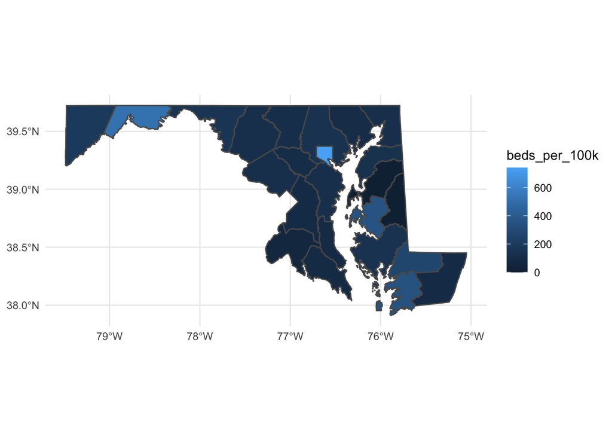

```r
ggplot() +
  geom_sf(data=md_beds_per_100k, aes(fill=beds_per_100k)) +
  theme_minimal()
```

This map is okay, but the color scale makes it hard to draw fine-grained differences. Let’s try applying the magma color scale we learned in the last chapter.

### Task: Run code

**Task** Run the following code. Describe the output in the space below. **Answer** Nice color scheme!

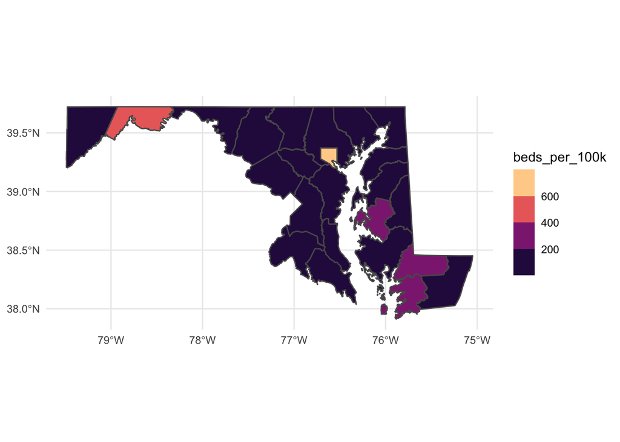

```r
ggplot() +
  geom_sf(data=md_beds_per_100k, aes(fill=beds_per_100k)) +
  theme_minimal() +
  scale_fill_viridis_b(option="magma")
```

The highest ranking counties stand out nicely in this version, but it’s still hard to make out fine-grained differences between counties.

So let’s change the color scale to a “log” scale, which will help us see those differences a bit more clearly.

### Task: Run code

**Task** Run the following code. Describe the output in the space below. What patterns do you see? **Answer** Added log scale to make differences more clear.

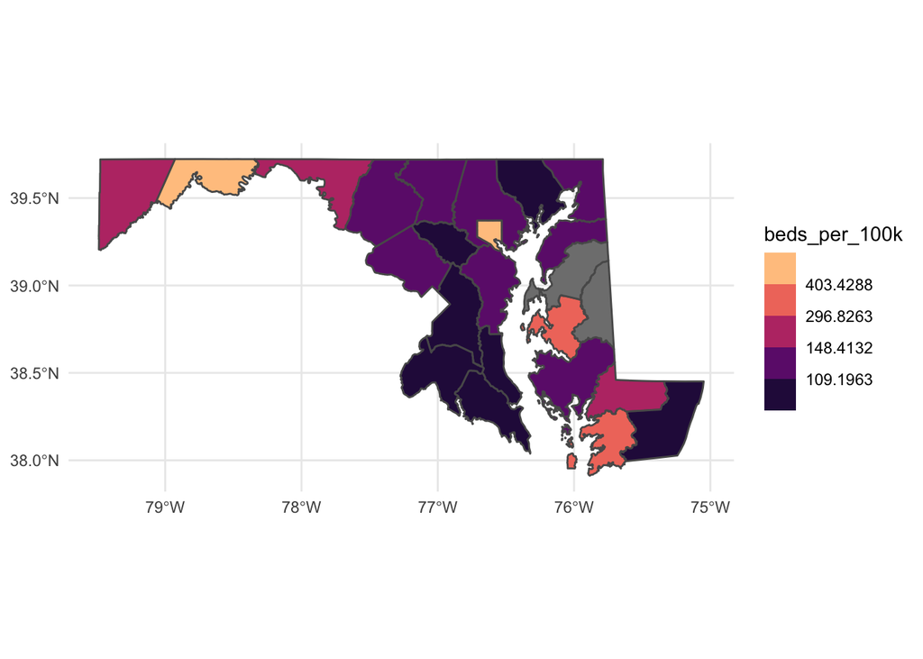

```r
ggplot() +
  geom_sf(data=md_beds_per_100k, aes(fill=beds_per_100k)) +
  theme_minimal() +
  scale_fill_viridis_b(option="magma",trans = "log")
```

Some interesting regional patterns finally emerge.